# SNP Filtering Atlantic Croaker (MUN) data set

# Heterozygosity and HWE

Generate summary statistics

```r
Inds <- as.data.frame(indNames(gen)) %>%
  rename(SAMPLE_ID = `indNames(gen)`) %>%
  separate(SAMPLE_ID, into = c("POP", "temp"), sep = "_", remove = FALSE) %>%
  select(-temp)
strata <- Inds
strata(gen) <- strata
# define groups using strata information
setPop(gen) <- ~POP
popNames(gen)
```

```
[1] "AFL" "BSL" "JKF" "SLT" "ULM"
```

```r
# generate genetic diversity stats
GenDiv <- adegenet::summary(gen)
dat <- hierfstat:::.genind2hierfstat(gen)
GenDiv2 <- basic.stats(dat)
```

Compare observed (Ho) and expected (He) heterozygosity for all individuals across all populations.

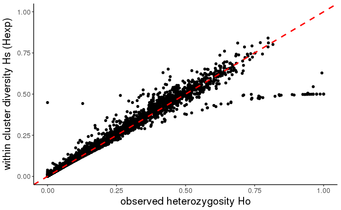

```r
# observed heterozygosity per locus
Ho <- as.data.frame(GenDiv$Hobs) %>%
  rownames_to_column("LOCUS") %>%
  rename(Ho = `GenDiv$Hobs`)
# expected heterozygosity per locus
Hs <- as.data.frame(GenDiv$Hexp) %>%
  rownames_to_column("LOCUS") %>%
  rename(Hexp = `GenDiv$Hexp`)
# expected and observed heterozysity per locus
Het <- left_join(Ho, Hs, by = "LOCUS")
# plot Ho vs Hs across all individuals
ggplot(Het, aes(x = Ho, y = Hexp)) +
  geom_point() +
  geom_abline(intercept = 0, slope = 1, color = "red", linetype = "dashed", size = 1) +
  xlim(0, 1) +
  ylim(0, 1) +
  labs(x = "observed heterozygosity Ho", y = "within cluster diversity Hs (Hexp)") +
  theme_standard
```

Identify loci that are now monomorphic and remove from data set:

```r
monomorphic <- filter(Ho, Ho == 0)
View(monomorphic)
monomorphic <- monomorphic$LOCUS
# remove flagged loci
removeloc <- c(monomorphic)
gen <- genind.rem.loci(gen, removeloc)
```

462 loci removed due to being monomorphic.

Compare distribution of observed heterozygosity (Ho) in each putative population:

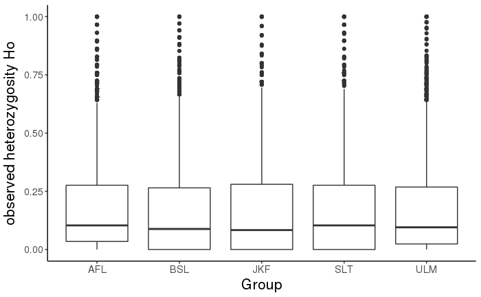

```r
Ho_per <- as.data.frame(GenDiv2$Ho) %>%
  rownames_to_column("LOCUS") %>%
  rename(AFL = `1`, BSL = `2`, JKF = `3`, SLT = `4`, ULM = `5`) %>%
  select(LOCUS, AFL, BSL, JKF, SLT, ULM) %>%
  gather(Group, Ho, 2:6)
# compare observed heterozygosity per locus and cluster
ggplot(Ho_per, aes(x = Group, y = Ho)) +
  geom_boxplot() +
  labs(x = "Group", y = "observed heterozygosity Ho") +
  theme_standard
```

Compare distribution of expected heterozygosity He, (within cluster diversity) in each putative population:

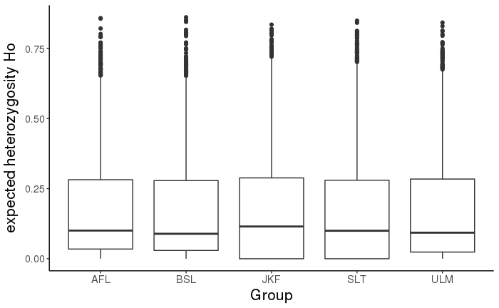

```r
# within cluster diversity/exp diversity per locus (rows) and cluster (columns)
Hs_per <- as.data.frame(GenDiv2$Hs) %>%
  rownames_to_column("LOCUS") %>%
  rename(AFL = `1`, BSL = `2`, JKF = `3`, SLT = `4`, ULM = `5`) %>%
  select(LOCUS, AFL, BSL, JKF, SLT, ULM) %>%
  gather(Group, Hs, 2:6)
# compare expected heterozygosity per locus and cluster
ggplot(Hs_per, aes(x = Group, y = Hs)) +
  geom_boxplot() +
  labs(x = "Group", y = "expected heterozygosity Ho") +
  theme_standard
```

Comparison of oberved vs. heterozygosity within each population:

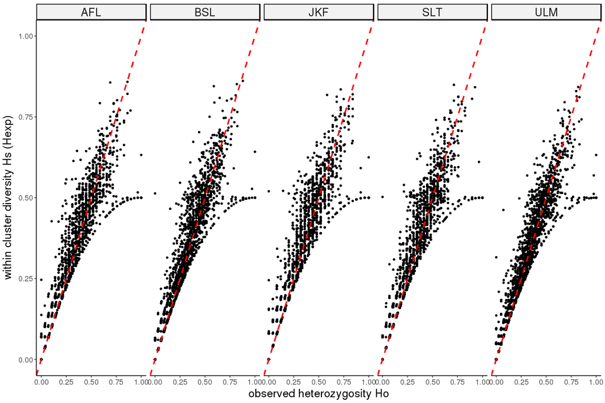

```r
# join data frames
Het_per <- left_join(Hs_per, Ho_per)
# plot per cluster
ggplot(Het_per, aes(x = Ho, y = Hs)) +
  geom_point(shape = 19, size = 1) +
  geom_abline(intercept = 0, slope = 1, color = "red", linetype = "dashed", size = 1) +
  xlim(0, 1) +
  ylim(0, 1) +
  facet_grid(. ~ Group) +
  labs(x = "observed heterozygosity Ho", y = "within cluster diversity Hs (Hexp)") +
  theme_standard
```

Test for deviations from Hardy-Weinberg equilibrium within each group (POP level):

```r
setPop(gen) <- ~POP
# create one genind object per sample location
gen_seppop <- seppop(gen)
gen_AFL <- gen_seppop$AFL
gen_BSL <- gen_seppop$BSL
gen_JKF <- gen_seppop$JKF
gen_SLT <- gen_seppop$SLT
gen_ULM <- gen_seppop$ULM
# test for deviations from HWE overall and per region (B = no. of replicates)
HWE_test <- hw.test(gen, B = 1000)
```

[output not shown]

Format output and view results:

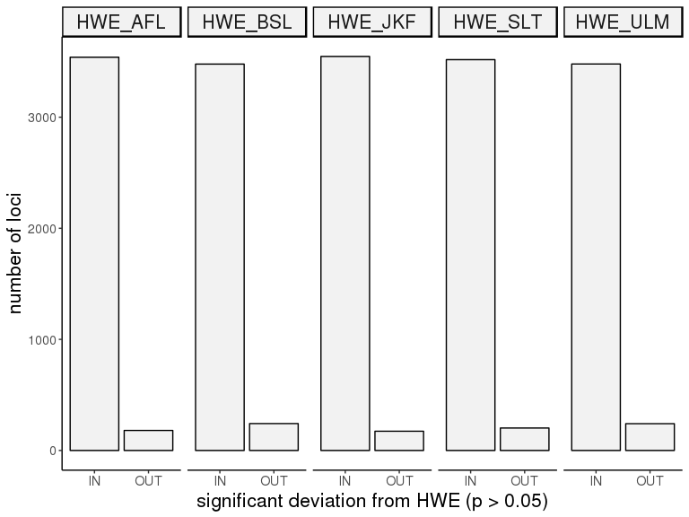

```r
# format put to combine p-values into one data frame
HWE <- as.data.frame(HWE_test) %>%
  select(Pr.exact) %>%
  rename(HWE = Pr.exact) %>%
  rownames_to_column("LOCUS")
HWE_AFL <- as.data.frame(HWE_test_AFL) %>%
  select(Pr.exact) %>%
  rename(HWE_AFL = Pr.exact) %>%
  rownames_to_column("LOCUS")
HWE <- left_join(HWE, HWE_AFL)
HWE_BSL <- as.data.frame(HWE_test_BSL) %>%
  select(Pr.exact) %>%
  rename(HWE_BSL = Pr.exact) %>%
  rownames_to_column("LOCUS")
HWE <- left_join(HWE, HWE_BSL)
HWE_JKF <- as.data.frame(HWE_test_JKF) %>%
  select(Pr.exact) %>%
  rename(HWE_JKF = Pr.exact) %>%
  rownames_to_column("LOCUS")
HWE <- left_join(HWE, HWE_JKF)
HWE_SLT <- as.data.frame(HWE_test_SLT) %>%
  select(Pr.exact) %>%
  rename(HWE_SLT = Pr.exact) %>%
  rownames_to_column("LOCUS")
HWE <- left_join(HWE, HWE_SLT)
HWE_ULM <- as.data.frame(HWE_test_ULM) %>%
  select(Pr.exact) %>%
  rename(HWE_ULM = Pr.exact) %>%
  rownames_to_column("LOCUS")
HWE <- left_join(HWE, HWE_ULM)
write.table(HWE, "results/HWEbypop",
            row.names = FALSE, col.names = TRUE, quote = FALSE)
# gather data into long format
HWE_long <- HWE %>%
  select(-HWE) %>%
  gather(POP, pval, 2:6) %>%
  mutate(HWE = ifelse(pval <= 0.05, "OUT", "IN"))
# plot data
ggplot(HWE_long, aes(x = HWE, position = "identity")) +
  geom_bar(color = "black", fill = "grey95") +
  labs(x = "significant deviation from HWE (p > 0.05)", y = "number of loci") +
  facet_grid( ~ POP) +
  theme_standard
```

Remove loci as necessary:

```r
# identify loci  of HWE
HWE_dev <- filter(HWE_long, pval <= 0.05)
temp <- HWE_dev %>%
  group_by(LOCUS) %>%
  count(HWE)
View(temp)
removeloc <- temp %>%
  filter(n > 3)
# remove flagged loci
gen <- genind.rem.loci(gen, removeloc$LOCUS)
gen
```

```
/// GENIND OBJECT /////////

 // 159 individuals; 3,682 loci; 17,996 alleles; size: 14.4 Mb

 // Basic content
   @tab:  159 x 17996 matrix of allele counts
   @loc.n.all: number of alleles per locus (range: 2-30)
   @loc.fac: locus factor for the 17996 columns of @tab
   @all.names: list of allele names for each locus
   @ploidy: ploidy of each individual  (range: 2-2)
   @type:  codom
   @call: .local(x = x, i = i, j = j, loc = ..1, drop = drop)

 // Optional content
   @pop: population of each individual (group size range: 25-42)
   @strata: a data frame with 2 columns ( SAMPLE_ID, POP )
```

38 loci removed as being out of HWE in more than 3 sample locations (putative populations).

# Run PCA to identify outlier individuals

# PCA

Scale alleles & perform PCA.

```r
gen
```

```
/// GENIND OBJECT /////////

 // 159 individuals; 3,682 loci; 17,996 alleles; size: 14.4 Mb

 // Basic content
   @tab:  159 x 17996 matrix of allele counts
   @loc.n.all: number of alleles per locus (range: 2-30)
   @loc.fac: locus factor for the 17996 columns of @tab
   @all.names: list of allele names for each locus
   @ploidy: ploidy of each individual  (range: 2-2)
   @type:  codom
   @call: .local(x = x, i = i, j = j, loc = ..1, drop = drop)

 // Optional content
   @pop: population of each individual (group size range: 25-42)
   @strata: a data frame with 2 columns ( SAMPLE_ID, POP )
```

```r
# create matrix with centered/scaled allele frequencies
# will also replace missing data
X <- scaleGen(gen, NA.method = "mean")
# perform PCA/retain top 3 PCs
PCA <- dudi.pca(X, center = FALSE, scale = FALSE,
                scannf = FALSE, nf = 10)
```

Plot eigenvalues of first 25 principle components.

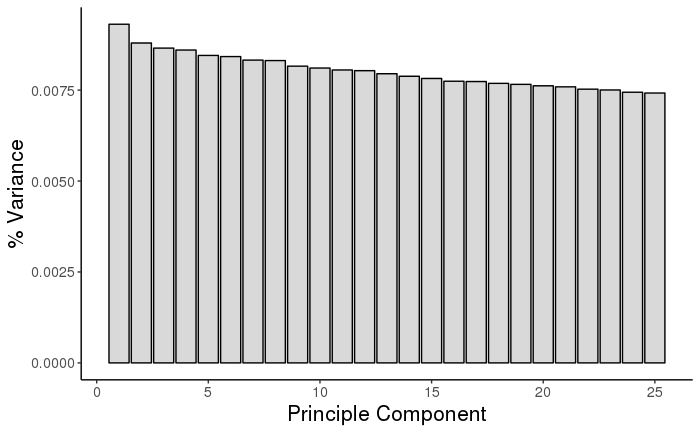

```r
# extract Eigenvalues of each PC & calculate % variance explained by each PC
eig <- eigenvalues(PCA)
# plot %variance explained by of top 25 PCs
plot.eigen.variance(eig)
```

## Analyze PCA results

Plot individuals by first two principle components

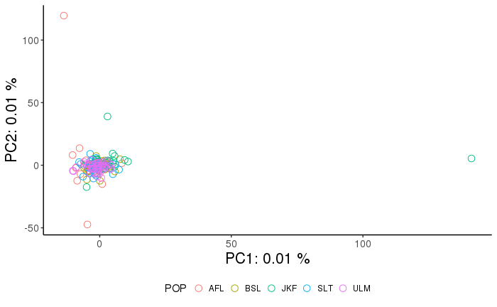

```r
# Individuals' contribution to PCs/calculate Loading per individual and PC
PC_ind <- PC.ind(PCA) %>%
  rename(SAMPLE_ID = LIB_ID)
# join individuals' contribution to PC with strata
PC_ind <- left_join(PC_ind, strata)
ggplot(PC_ind, aes(x = Axis1, y = Axis2, color = POP)) +
  geom_point(shape = 1, size = 3) +
  labs(x = paste("PC1:", round(eig[1, 3], digits = 2), "%"), y = paste("PC2:", round(eig[2, 3], digits = 2), "%")) +
  theme_standard
```

# Final data set

Write file with filtered data set:

```r
# convert to data frame and write to file
df <- genind2df(gen,
                usepop = TRUE,
                sep = ":", oneColPerAll = FALSE) %>%
  select(-pop)
write.table(df, "data/MUN.genotypes",
            row.names = TRUE, col.names = TRUE,
            sep = "\t", quote = FALSE)
library(radiator)
tidy <- tidy_genomic_data(gen)
```

```
#######################################################################
##################### radiator::tidy_genomic_data #####################
#######################################################################
```

```
Tidying the genind object ...
Importing the data frame ...
Erasing genotype: no
Using markers common in all populations:
    Number of markers before = 3682
    Number of markers removed = 0
    Number of common markers between populations) = 3682
Scanning for monomorphic markers...
Scanning for monomorphic markers...
    Number of markers before = 3682
    Number of monomorphic markers removed = 0
```

```
############################### RESULTS ###############################
```

```
Tidy data written in global environment
Data format: genind
Multiallelic data

Tidy genomic data:
    Number of common markers: 3682
    Number of chromosome/contig/scaffold: no chromosome info
    Number of individuals: 159
    Number of populations: 5
Computation time: 51 sec
```

```
################ radiator::tidy_genomic_data completed ################
```

```r
# write genepop formatted file
write_genepop(tidy, filename = "data/Croaker_filtered.gen",
              pop.levels = NULL,
              genepop.header = "CROAKER FILTERED DATA SET",
              markers.line = FALSE)
```

Write files with individuals and Contigs still contained in data set and use to filter vcf file.

```r
keeploci <- as.data.frame(locNames(gen)) %>%
  rename(LOCUS = `locNames(gen)`)
write.table(keeploci, "data/filtered.loci",
            col.names = FALSE, row.names = FALSE, quote = FALSE)
keepind <- as.data.frame(indNames(gen)) %>%
  rename(INDV = `indNames(gen)`)
write.table(keepind, "data/filtered.ind",
            col.names = FALSE, row.names = FALSE, quote = FALSE)
```